# Spherical HRTF Model

January 1, 2019

#### *Allowing you to synthesize binaural sound from a monaural sound*

In this notebook, we showed how to use a spherical-head model to estimate head-related transfer functions (HRTFs) at a certain azimuth, which later can be used to synthesize binaural sound. All equations we introduced here are based on the following reference.

- C. Phillip Brown and Richard O. Duda, "A Structural Model for Binaural Sound Synthesis, " *IEEE Transactions on Speech & Audio Processing*, **6**(5), 476–488, 1998.

### Spherical Model

The spherical model is represented as a single-pole and single-zero filter:

\begin{equation} H_H(\omega,\theta) = \displaystyle \frac {1 + i \displaystyle \frac{\alpha(\theta)\omega}{2\omega_0}} {1 + i \displaystyle \frac{\omega}{2\omega_0}} e^{-j \omega T_d(\theta)} \end{equation}

where the frequency $\omega_0 (= c/a)$ is relatd to the radius of the head $a$ (8.75-cm average radius of an adult) and the speed of sound $c$ (approximately 343 m/s). The model is determined by the angle dependent parameters:

\begin{equation} T_d(\theta) = \frac{a}{c} + \begin{cases} \displaystyle -\frac{a}{c} \cos(\theta) & \quad \text{if } 0 \leq \theta < \frac{\pi}{2}\\ \displaystyle \frac{a}{c} \bigg(|\theta|-\frac{\pi}{2}\bigg) & \quad \text{if } \frac{\pi}{2} \leq \theta < \pi \end{cases} \end{equation}

and

\begin{equation} \alpha(\theta) = \bigg(1+\frac{\alpha_{\textrm{min}}}{2}\bigg) + \bigg(1-\frac{\alpha_{\textrm{min}}}{2}\bigg) \cos\bigg(\frac{\theta}{\theta_{\textrm{min}}}\pi\bigg) \end{equation}

### DEMO using GNU Octave

According to the paper, the parameters of the model are set to $a=$ 0.0875 m, $\alpha_{\textrm{min}}=$ 0.1, $c=$ 343 m/s, and $\theta_{\textrm{min}} =$ 150$^\circ$. Since every individual has their own parameters, adjustment can be done easily by listening to binaural sound and feeling the perceived direction.

**Please note that the model discussed here is limited to the frontal half space from 0$^\circ$ to 180$^\circ$ azimuth.**

```matlab
pkg load signal % load signal package
```

Define the parameters

```matlab
% parameters below may change depending on each individual
c = 343;
a = 0.0831;
Q_min = deg2rad(130);
alpha_min = 0.1;
wo = c/a;
```

Define functions for $T_d(\theta)$ and $\alpha(\theta)$

```matlab
Td = @(Q) (a/c) + (0<=Q&Q<pi/2).*(-a/c).*cos(Q) + (pi/2<=Q&Q<=pi).*(a/c).*(abs(Q)-pi/2);
alpha = @(Q) (1+(alpha_min/2))+(1-(alpha_min/2))*cos((Q/Q_min)*pi);
```

Finally, define the model $H_H(\omega,\theta)$. We assume that 0$^\circ$ is in the front. However, 0$^\circ$ is actually on the left according to the model. In that case, we need to add $\pi$/2 as a compensation.

```matlab
HH = @(w,Q) [(1+1i*(w.*alpha(Q))/(2*wo))./(1+1i*(w/(2*wo)))].*exp(-1i*w.*Td(Q));
HH_L = @(w,Q) HH(w,Q+pi/2);      % for left ear
HH_R = @(w,Q) HH(w,pi-(Q+pi/2)); % for right ear
```

Extract impulse response for left and right ears at 40$^\circ$

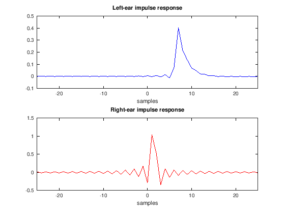

```matlab
Q_target = deg2rad(40); % the target direction
fs = 16000; % sampling rate
nfft = 512; % length for IFFT

% prepare the frequency responses
F = linspace(0,1,nfft/2)*fs/2;
XL = HH_L(2*pi*F,Q_target);
XL = [XL conj(XL(end:-1:1))];
XR = HH_R(2*pi*F,Q_target);
XR = [XR conj(XR(end:-1:1))];

% apply invers FFT (IFFT) to obtain the impulses
hrtf_L = real(ifft(XL,nfft));
hrtf_L = [hrtf_L(nfft/2+1:end) hrtf_L(1:nfft/2)];
hrtf_R = real(ifft(XR,nfft));
hrtf_R = [hrtf_R(nfft/2+1:end) hrtf_R(1:nfft/2)];

ntime = (0:nfft-1)-nfft/2;

subplot(211)
plot(ntime,hrtf_L,'b')
title('Left-ear impulse response')
xlabel('samples')
xlim([-25 25])

subplot(212)
plot(ntime,hrtf_R,'r')
title('Right-ear impulse response')
xlabel('samples')
xlim([-25 25])
```

Now it is time to listen to binaural sound. (Download a monaural sound here: sp1.wav)

```matlab
[x fs] = audioread('sp1.wav');

Gc = 0.5; % to avoid audio clipping

% convolution
sl = fftfilt(hrtf_L'*Gc,x);
sr = fftfilt(hrtf_R'*Gc,x);

sound([sl sr],fs,16)
```

[output not shown]

### Interaural Phase and Level Difference (IPD & ILD)

For binaural speech enhancement or localization algoritm, ILD and IPD are important features. Here below shows their relationship against azimuth.

Define ILD and IPD model

```matlab
XISmodel = @(w,Q) HH_R(w,Q)./HH_L(w,Q);
IPDmodel = @(w,Q) angle(XISmodel(w,Q));
ILDmodel = @(w,Q) 20*log10(abs(XISmodel(w,Q)));
```

Plot them

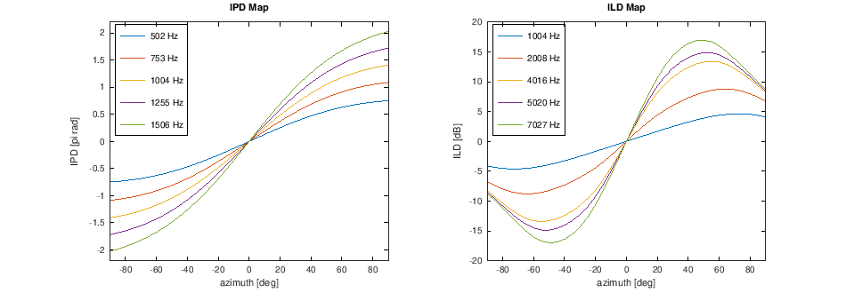

```matlab
freq = linspace(0,1,256)*fs/2;
azim = -90:5:90;

[AZ FR] = meshgrid(azim,freq);
IPD = unwrap(IPDmodel(2*pi*FR,deg2rad(AZ)));
ILD = ILDmodel(2*pi*FR,deg2rad(AZ));

id_IPD = [17 25 33 41 49];
legend_IPD = strrep (mat2str(round(freq(id_IPD)))(2:end-1),' ', ' Hz","');
legend_IPD = ['legend("' legend_IPD ' Hz","location", "northwest")'];

id_ILD = [33 65 129 161 225];
legend_ILD = strrep (mat2str(round(freq(id_ILD)))(2:end-1),' ', ' Hz","');
legend_ILD = ['legend("' legend_ILD ' Hz","location", "northwest")'];

figure(1,"position",[0,0,950,330])

subplot(121)
plot(azim,IPD(id_IPD,:)/pi)
xlim([-90 90])
ylim([-2.2 2.2])
xlabel('azimuth [deg]')
ylabel('IPD [pi rad]')
eval(legend_IPD)
title('IPD Map')

subplot(122)
plot(azim,ILD(id_ILD,:))
xlim([-90 90])
ylim([-20 20])
xlabel('azimuth [deg]')
ylabel('ILD [dB]')
eval(legend_ILD)
title('ILD Map')
```

If we compare both figures with the figures from this paper: [(Nakashima, 2003)](https://www.jstage.jst.go.jp/article/ast/24/4/24_4_172/_pdf). Only IPD map has very similar patterns. However, our ILD map has lower level compared to that of the Nakashima paper.